# Housing Model

Connor Briggs, Jackson Hamilton, and Olivia Snyder

5/6/2020

```r
library(readxl)
library(leaps)
library(glmnet)
library(pls)
housing <- read_xlsx("Housing.xlsx")
housing$sld <- ifelse(housing$status == "sld", 1, 0)
housing$pen <- ifelse(housing$status == "pen", 1, 0)
housing$adams <- ifelse(housing$elem == "adams", 1, 0)
housing$edge <- ifelse(housing$elem == "edge", 1, 0)
housing$edison <- ifelse(housing$elem == "edison", 1, 0)
housing$harris <- ifelse(housing$elem == "harris", 1, 0)
housing$parker <- ifelse(housing$elem == "parker", 1, 0)
```

## 1) Part A: Previous Model

- Consider the model that you arrived at in the previous project as the first candidate model.

```r
housing2 <- housing[c(-74, -66),]
model.f <- lm(price ~ size + lot + harris + edison + size:lot + size:harris + lot:harris + sld:edison + sld, data = housing2)
summary(model.f)
```

```
##
## Call:
## lm(formula = price ~ size + lot + harris + edison + size:lot +
##     size:harris + lot:harris + sld:edison + sld, data = housing2)
##
## Residuals:
##      Min       1Q   Median       3Q      Max
## -107.140  -29.680   -5.441   30.970   97.335
##
## Coefficients:
##             Estimate Std. Error t value Pr(>|t|)
## (Intercept)   81.198    180.274   0.450 0.653934
## size          72.000     92.039   0.782 0.436937
## lot           31.119     41.897   0.743 0.460347
## harris        55.128    198.524   0.278 0.782147
## edison        33.552     25.923   1.294 0.200216
## sld          -45.818     11.084  -4.134 0.000106 ***
## size:lot      -8.245     21.360  -0.386 0.700770
## size:harris   39.796     93.035   0.428 0.670265
## lot:harris   -24.045     10.296  -2.335 0.022669 *
## edison:sld    64.928     30.399   2.136 0.036523 *
## ---
## Signif. codes:  0 '***' 0.001 '**' 0.01 '*' 0.05 '.' 0.1 ' ' 1
##
## Residual standard error: 41.2 on 64 degrees of freedom
## Multiple R-squared:  0.5584, Adjusted R-squared:  0.4963
## F-statistic: 8.992 on 9 and 64 DF,  p-value: 1.251e-08
```

The final model from the first project was loaded in and recreated based on the criteria decided previously. The individual terms for the interaction parts of the model were added in as well.

## 2) Part B: Forward Selection

- Create a second candidate model by using regsubsets over the entire data set. You can decide whether you prefer overall selection, forward selection, or backward selection, and you can decide which statistic you will use to determine the best model from the regsubsets process. Just conduct a justifiable model selection process and report the predictors in your final model.

```r
regfwdfull <- regsubsets(price ~ . - id - agestandardized - status - elem, data = housing, nvmax = 13, method = "forward")
regfwdfullsummary <- summary(regfwdfull)

regfwdfullsummary
```

```
## Subset selection object
## Call: regsubsets.formula(price ~ . - id - agestandardized - status -
##     elem, data = housing, nvmax = 13, method = "forward")
## 13 Variables  (and intercept)
##            Forced in Forced out
## size           FALSE      FALSE
## lot            FALSE      FALSE
## bath           FALSE      FALSE
## bedrooms       FALSE      FALSE
## yearbuilt      FALSE      FALSE
## garagesize     FALSE      FALSE
## sld            FALSE      FALSE
## pen            FALSE      FALSE
## adams          FALSE      FALSE
## edge           FALSE      FALSE
## edison         FALSE      FALSE
## harris         FALSE      FALSE
## parker         FALSE      FALSE
## 1 subsets of each size up to 13
## Selection Algorithm: forward
##           size lot bath bedrooms yearbuilt garagesize sld pen adams edge edison
## 1  ( 1 )  " "  " " " "  " "      " "       "*"        " " " " " "   " "  " "
## 2  ( 1 )  " "  " " " "  " "      " "       "*"        " " " " " "   " "  "*"
## 3  ( 1 )  " "  " " " "  " "      " "       "*"        " " " " " "   " "  "*"
## 4  ( 1 )  " "  "*" " "  " "      " "       "*"        " " " " " "   " "  "*"
## 5  ( 1 )  " "  "*" " "  " "      " "       "*"        "*" " " " "   " "  "*"
## 6  ( 1 )  "*"  "*" " "  " "      " "       "*"        "*" " " " "   " "  "*"
## 7  ( 1 )  "*"  "*" " "  "*"      " "       "*"        "*" " " " "   " "  "*"
## 8  ( 1 )  "*"  "*" " "  "*"      " "       "*"        "*" " " " "   " "  "*"
## 9  ( 1 )  "*"  "*" " "  "*"      " "       "*"        "*" "*" " "   " "  "*"
## 10  ( 1 ) "*"  "*" "*"  "*"      " "       "*"        "*" "*" " "   " "  "*"
## 11  ( 1 ) "*"  "*" "*"  "*"      "*"       "*"        "*" "*" " "   " "  "*"
## 12  ( 1 ) "*"  "*" "*"  "*"      "*"       "*"        "*" "*" " "   "*"  "*"
## 13  ( 1 ) "*"  "*" "*"  "*"      "*"       "*"        "*" "*" "*"   "*"  "*"
##           harris parker
## 1  ( 1 )  " "    " "
## 2  ( 1 )  " "    " "
## 3  ( 1 )  "*"    " "
## 4  ( 1 )  "*"    " "
## 5  ( 1 )  "*"    " "
## 6  ( 1 )  "*"    " "
## 7  ( 1 )  "*"    " "
## 8  ( 1 )  "*"    "*"
## 9  ( 1 )  "*"    "*"
## 10  ( 1 ) "*"    "*"
## 11  ( 1 ) "*"    "*"
## 12  ( 1 ) "*"    "*"
## 13  ( 1 ) "*"    "*"
```

We chose to use forward selection when creating our second model because we had mostly followed a backwards selection process for our first model. This should hopefully yield different results from the previous model.

```r
coef(regfwdfull, 13)
```

```
##  (Intercept)         size          lot         bath     bedrooms    yearbuilt
## -130.6298116   72.5239969   10.5661045    5.4464575  -12.0425300    0.1271215
##   garagesize          sld          pen        adams         edge       edison
##    7.6954380  -37.0331164  -19.0612278   -1.2170918    3.4292422   83.3468986
##       harris       parker
##   49.1779001  -15.6150038
```

```r
regfwdfullsummary$adjr2
```

```
##  [1] 0.1166628 0.2438794 0.3215207 0.3871343 0.4156376 0.4544754 0.4630622
##  [8] 0.4688072 0.4728210 0.4677897 0.4607066 0.4525025 0.4436833
```

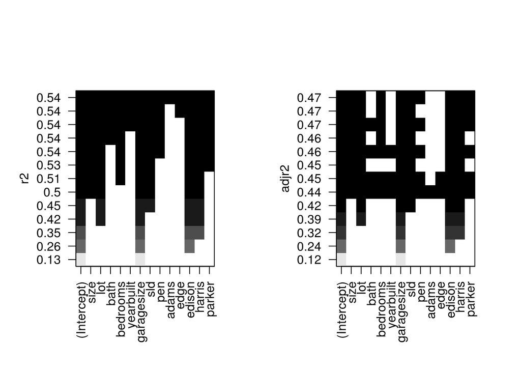

```r
par(mfrow=c(1, 2))
plot(regfwdfull, scale = "r2")
plot(regfwdfull, scale = "adjr2")
```

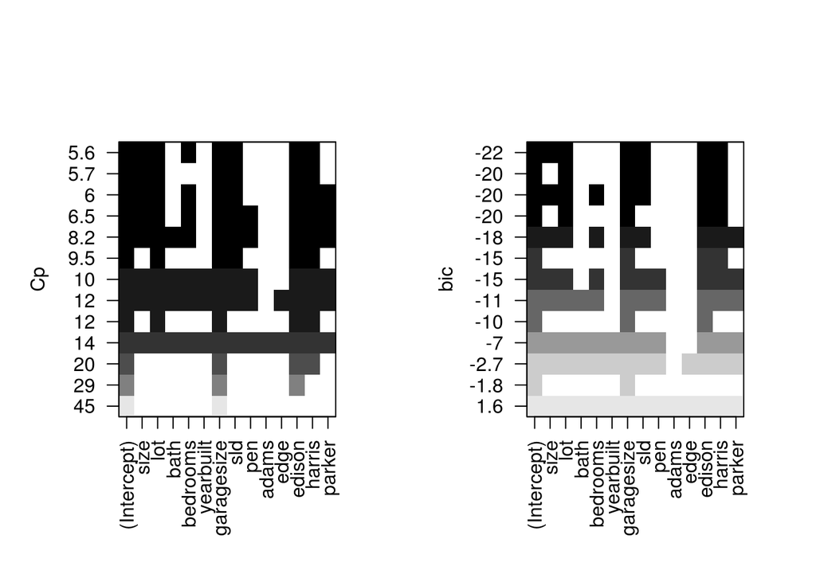

```r
par(mfrow=c(1, 2))
plot(regfwdfull, scale = "Cp")
plot(regfwdfull, scale = "bic")
```

The coefficients for a model using all parameters was printed as well as the adjusted R-squared value for each number of parameters. As can be seen, after the ninth parameter, adjusted R-squared begins to fall off. Plots for r2, adjr2, cp, and bic were created. What can be noticed immediately, is that the best models for each value size, lot, garagesize, sold status, edison, and harris all appear.

```r
par(mfrow=c(2,2))
plot(regfwdfullsummary$rsq, xlab = "Number of Variables", ylab = "RSQ", type = "l")

plot(regfwdfullsummary$adjr2, xlab = "Number of Variables", ylab = "Adjusted RSq", type = "l")
which.max(regfwdfullsummary$adjr2)
```

```
## [1] 9
```

```r
points(9, regfwdfullsummary$adjr2[9], col = "red", cex = 2, pch = 20)

plot(regfwdfullsummary$cp, xlab = "Number of Variables", ylab = "Cp", type = 'l')
which.min(regfwdfullsummary$cp)
```

```
## [1] 7
```

```r
points(7, regfwdfullsummary$cp[7], col = "red", cex = 2, pch = 20)

plot(regfwdfullsummary$bic, xlab = "Number of Variables", ylab = "BIC", type = 'l')
which.min(regfwdfullsummary$bic)
```

```
## [1] 6
```

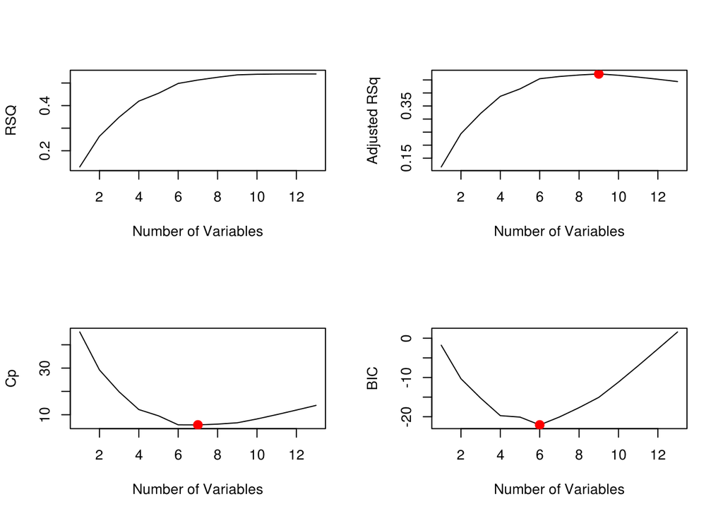

```r
points(6, regfwdfullsummary$bic[6], col = "red", cex = 2, pch = 20)
```

```r
coef(regfwdfull, 6)
```

```
## (Intercept)        size         lot  garagesize         sld      edison
##    91.40680    61.60675    10.41055    14.81474   -30.45411    80.84791
##      harris
##    58.40366
```

```r
model2 <- lm(price ~ size + lot + garagesize + sld + edison + harris, data = housing)
summary(model2)
```

```
##
## Call:
## lm(formula = price ~ size + lot + garagesize + sld + edison +
##     harris, data = housing)
##
## Residuals:
##    Min     1Q Median     3Q    Max
## -97.87 -29.02  -0.92  28.27  99.98
##
## Coefficients:
##             Estimate Std. Error t value Pr(>|t|)
## (Intercept)   91.407     49.941   1.830 0.071524 .
## size          61.607     25.185   2.446 0.016993 *
## lot           10.411      3.396   3.065 0.003102 **
## garagesize    14.815      7.746   1.912 0.059970 .
## sld          -30.454     11.541  -2.639 0.010274 *
## edison        80.848     14.745   5.483 6.43e-07 ***
## harris        58.404     14.390   4.059 0.000128 ***
## ---
## Signif. codes:  0 '***' 0.001 '**' 0.01 '*' 0.05 '.' 0.1 ' ' 1
##
## Residual standard error: 44.56 on 69 degrees of freedom
## Multiple R-squared:  0.4981, Adjusted R-squared:  0.4545
## F-statistic: 11.41 on 6 and 69 DF,  p-value: 7.972e-09
```

Model 2 was created using the six best variables for a forward regression model. The variables selected exactly match the variables previously discussed as being included in the best plots. Based on the summary, we do have a significant model.

## 3) Part C: Training/Test Split

- Create a training/test split of the data by which roughly half of the 76 observations are training data and half are test data.

```r
set.seed(1)
train <- sample(76, 38, replace = FALSE)
test <- (1:76)[-train]
```

Half of the row numbers from the Housing data were sampled to be training data and the rest were saved as test data.

## 4) Part D: Regsubsets Using Training Data

- Now use regsubsets over only the training data to determine the number of predictors that should be in your final model. Then use regsubsets over the entire data set with the determined number of variables to determine your third candidate model.

```r
set.seed(1)
regfwdtrain <- regsubsets(price ~ . - id - agestandardized - status - elem, data = housing[train,], nvmax = 13)
testmatrix <- model.matrix(price ~ . - id - agestandardized - status - elem, data = housing[test,])
val.errors <- rep(NA, 13)
for (i in 1:13)
{
  coefi = coef(regfwdtrain, id = i)
  pred = testmatrix[, names(coefi)] %*% coefi
  val.errors[i] = mean((housing$price[test] - pred)^2)

}

val.errors
```

```
##  [1] 4549.240 4386.555 3309.531 3000.454 3077.233 2696.617 2809.005 2835.293
##  [9] 2990.537 2849.631 2892.237 2918.906 2920.493
```

```r
which.min(val.errors)
```

```
## [1] 6
```

```r
coef(regfwdtrain, which.min(val.errors))
```

```
## (Intercept)        size         lot         sld      edison      harris
##    71.54819    77.71805    16.94214   -39.78227    73.31642    54.49392
##      parker
##   -30.56152
```

```r
model3 <- lm(price ~ size + lot + sld + edison + harris + parker, data = housing[train, ])
summary(model3)
```

```
##
## Call:
## lm(formula = price ~ size + lot + sld + edison + harris + parker,
##     data = housing[train, ])
##
## Residuals:
##     Min      1Q  Median      3Q     Max
## -68.675 -29.160  -4.114  33.569  56.594
##
## Coefficients:
##             Estimate Std. Error t value Pr(>|t|)
## (Intercept)   71.548     72.974   0.980 0.334452
## size          77.718     38.879   1.999 0.054443 .
## lot           16.942      3.482   4.866 3.16e-05 ***
## sld          -39.782     12.955  -3.071 0.004417 **
## edison        73.316     18.380   3.989 0.000377 ***
## harris        54.494     21.195   2.571 0.015161 *
## parker       -30.562     14.527  -2.104 0.043612 *
## ---
## Signif. codes:  0 '***' 0.001 '**' 0.01 '*' 0.05 '.' 0.1 ' ' 1
##
## Residual standard error: 37.07 on 31 degrees of freedom
## Multiple R-squared:  0.6928, Adjusted R-squared:  0.6333
## F-statistic: 11.65 on 6 and 31 DF,  p-value: 8.315e-07
```

```r
model3.mse <- predict(model3, housing[test,])
model3.mse <- colMeans((housing[test, 2] - model3.mse)^2)
```

## 5) Part E: Lasso Regression

- Next, use either Ridge Regression or Lasso Regression with the training data, and use cross validation via the cv.glmnet function to determine the best λ value. The model from this step with the best λ value will be your fourth candidate model.

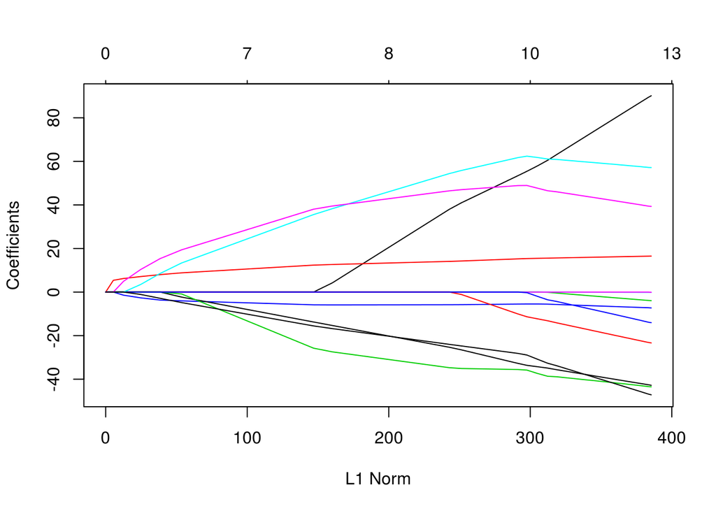

```r
set.seed(1)
grid=10^seq(10,-2,length=100)
x <- model.matrix(price ~ . - id - agestandardized - status - elem, data = housing)[,-1]
y <- housing$price
lasso.mod <- glmnet(x[train, ], y[train], alpha = 1)
plot(lasso.mod)
```

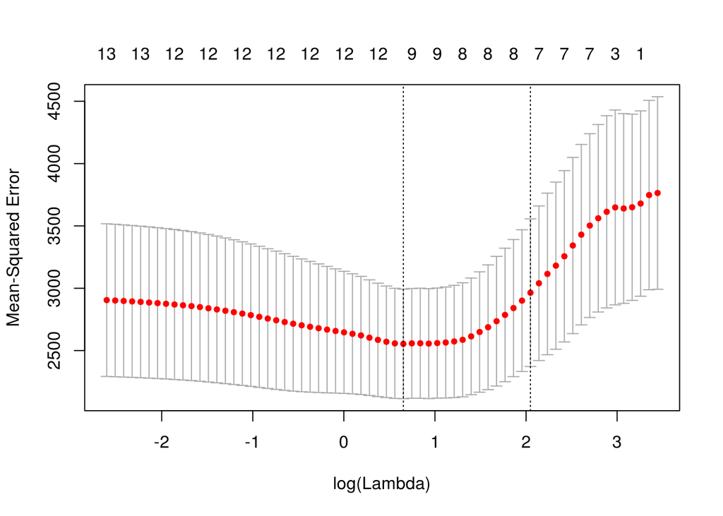

```r
cv.out <- cv.glmnet(x[train, ], y[train], alpha = 1)
plot(cv.out)
```

```r
bestlam <- cv.out$lambda.min
bestlam
```

```
## [1] 1.921188
```

```r
lasso.pred <- predict(lasso.mod, s = bestlam, newx = x[test,])
lasso.mse <- mean((lasso.pred-y[test])^2)
out <- glmnet(x, y, alpha=1, lambda =  grid)
lasso.coef <- predict(out, type = "coefficients", s = bestlam)[1:14,]
model4 <- lasso.coef[lasso.coef!=0]
model4
```

```
##  (Intercept)         size          lot         bath     bedrooms    yearbuilt
## 109.36623131  59.75569955   8.68090946   5.03647483 -10.39853354   0.01680312
##   garagesize          sld          pen       edison       harris       parker
##   9.54285670 -28.21596547  -5.92293603  69.08580903  41.90434375 -13.86086532
```

Next, we did a lasso model of our data over the training set. The best lambda value was found to be aproximately 1.9 based on cross validation. The coefficients for the lasso model with the best lambda value became our model 4. It contains 11 predictors, and includes bath, bedrooms, yearbuilt, and pen; which had not been seen previously in our models.

## 6) Part F: Partial Least Squares Regression

- Finally, use either principal components regression or partial least squares regression for the training data. Use cross validation (see the class notes or the Chapter 6 Lab from the text) to help you determine the number of components in the model and briefly explain your choice. This model will be your 5th candidate model.

```r
housing.pls <- read_xlsx("Housing.xlsx")
x <- model.matrix(price~. , data=housing.pls)[,-1]
y <- housing.pls$price
y.test <- y[test]
set.seed(1)
pls.fit <- plsr(price~., data=housing.pls,subset=train,scale=TRUE,validation="CV")
summary(pls.fit)
```

[output not shown]

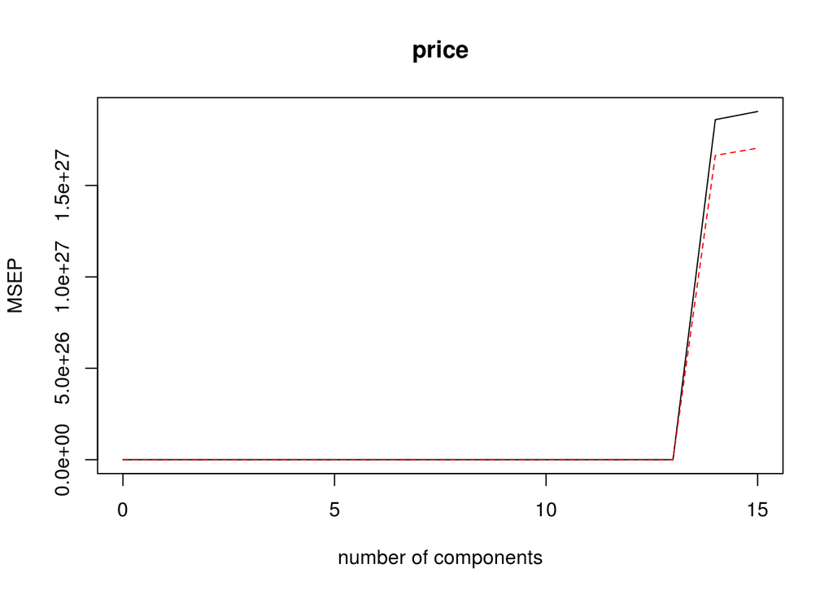

```r
validationplot(pls.fit,val.type="MSEP")
```

```r
pls.pred <- predict(pls.fit,x[test,],ncomp=2)
pls.mse <- mean((pls.pred-y.test)^2)
pls.fit <- plsr(price ~ ., data=housing.pls, scale=TRUE, ncomp=2)
summary(pls.fit)
```

```
## Data:    X dimension: 76 15
##  Y dimension: 76 1
## Fit method: kernelpls
## Number of components considered: 2
## TRAINING: % variance explained
##        1 comps  2 comps
## X        17.59    31.60
## price    37.79    50.85
```

A partial least squares regression was then done for the training section of the Housing data. Through cross validation, the best model was found to be two components, as this was the value at which the CV was at its smallest. A partial least squares model was fit with two components and become our fifth and final model.

## 7) Part G: Mean Square Error and Conclusion

- For each of the five candidate models, calculate the mean square error for predicting the outcomes in the test data set that you created in part c. Based on this comparison, which model do you prefer for this situation?

```r
price.test <- colMeans((colMeans(housing[test,2]) - housing[test,1])^2)

#First project
model1.mse <- colMeans((housing[test, 2] - predict(model.f, housing[test,]))^2)
model1.mse
```

```
##    price
## 1711.957
```

```r
1 - model1.mse / price.test
```

```
##    price
## 0.973866
```

```r
#Forward selection
model2.mse <- colMeans((housing[test, 2] - predict(model2, housing[test,]))^2)
model2.mse
```

```
##    price
## 2189.266
```

```r
1 - model2.mse / price.test
```

```
##     price
## 0.9665796
```

```r
#Training
model3.mse
```

```
##    price
## 2696.617
```

```r
1 - model3.mse / price.test
```

```
##     price
## 0.9588346
```

```r
#Lasso
lasso.mse
```

```
## [1] 2633.621
```

```r
1 - lasso.mse / price.test
```

```
##        id
## 0.9597963
```

```r
#Pls
pls.mse
```

```
## [1] 2834.941
```

```r
1 - pls.mse / price.test
```

```
##       id
## 0.956723
```

The MSE for each of the five models was printed as long as each models predictive accuracy over the test data. As can be seen, the origional model from the previous project minimized the errors over the test data. The second best was the forward selection created by us, then the lasso model, then forward selection with training, and finally the partial least squares model. As such, the model from the previous project is still our prefered model. The equation is
$$price = 81.198+72.000(size)+31.119(lot)+55.128(harris)+33.552(edison)-45.818(sld)-8.245(size:lot)+39.796(size:harris)-24.045(lot:harris)+64.928(sld:edison)$$
for our final model.